## **Name:** First Last

## **Computing ID:** ID

# Lab 2: Machine Learning Evaluation (100 Points)

```python
import pandas as pd
import numpy as np
import matplotlib.pyplot as plt

from sklearn.model_selection import train_test_split, cross_val_score
from sklearn.preprocessing import LabelEncoder, MinMaxScaler, StandardScaler, label_binarize
from sklearn.linear_model import LogisticRegression
from sklearn.neighbors import KNeighborsClassifier
from sklearn.metrics import accuracy_score, precision_score, recall_score, f1_score, roc_curve, auc
from sklearn.metrics import confusion_matrix, ConfusionMatrixDisplay
```

# **Candidate Messy Datasets for Part 1:**

- Tidy Tuesday
  - https://github.com/rfordatascience/tidytuesday/tree/main/data
- Hugging Face
  - https://huggingface.co/datasets/nateraw/airplane-crashes-and-fatalities
- Kaggle
  - https://www.kaggle.com/datasets/borapajo/food-choices?select=food_coded.csv
  - https://www.kaggle.com/datasets/mahnazarjmand/breast-cancer-data?resource=download

## Part 1: KNN and Regression Model Evaluation (30 Points)

## **Question 1 (15 points):**

## Read in or load a dataset as a Pandas DataFrame with at least 5 features (columns) and a categorical target column.

## Create a new DataFrame called clean_df that incorporates these preprocessing steps in **separate cells**. Complete each step regardless of if they have no effect on your data:

0. Call dtypes on the DataFrame
1. Drop rows that are completely empty
2. Replace missing values ("null", 0, empty strings) with proper NaNs
3. Impute NaNs using any method that sklearn supports
4. Drop any features that seem highly uncorrelated to your target so long as you still retain at least 5 features
5. Normalize and/or scale numerical columns using any method that sklearn supports
6. Encode any categorical columns using appropriate method (ordinal, one hot encoding)
7. Any additional preprocessing required for your data (ie: removing dollar signs from string columns and casting it is a float)

```python
df = pd.read_csv("../data/brest_cancer_data.csv")

df.dtypes
```

```
id                           int64
diagnosis                   object
radius_mean                float64
texture_mean               float64
perimeter_mean             float64
area_mean                  float64
smoothness_mean            float64
compactness_mean           float64
concavity_mean             float64
concave points_mean        float64
symmetry_mean              float64
fractal_dimension_mean     float64
radius_se                  float64
texture_se                 float64
perimeter_se               float64
area_se                    float64
smoothness_se              float64
compactness_se             float64
concavity_se               float64
concave points_se          float64
symmetry_se                float64
fractal_dimension_se       float64
radius_worst               float64
texture_worst              float64
perimeter_worst            float64
area_worst                 float64
smoothness_worst           float64
compactness_worst          float64
concavity_worst            float64
concave points_worst       float64
symmetry_worst             float64
fractal_dimension_worst    float64
Unnamed: 32                float64
dtype: object
```

```python
df = df.drop(columns=["Unnamed: 32"])

df = df.dropna(how='all')

df.sample(5)
```

|  | id | diagnosis | radius_mean | texture_mean | perimeter_mean | area_mean | smoothness_mean | compactness_mean | concavity_mean | concave points_mean | ... | radius_worst | texture_worst | perimeter_worst | area_worst | smoothness_worst | compactness_worst | concavity_worst | concave points_worst | symmetry_worst | fractal_dimension_worst |
| --- | --- | --- | --- | --- | --- | --- | --- | --- | --- | --- | --- | --- | --- | --- | --- | --- | --- | --- | --- | --- | --- |
| 55 | 85759902 | B | 11.52 | 18.75 | 73.34 | 409.0 | 0.09524 | 0.05473 | 0.03036 | 0.02278 | ... | 12.84 | 22.47 | 81.81 | 506.2 | 0.1249 | 0.0872 | 0.09076 | 0.06316 | 0.3306 | 0.07036 |
| 364 | 9010877 | B | 13.40 | 16.95 | 85.48 | 552.4 | 0.07937 | 0.05696 | 0.02181 | 0.01473 | ... | 14.73 | 21.70 | 93.76 | 663.5 | 0.1213 | 0.1676 | 0.13640 | 0.06987 | 0.2741 | 0.07582 |
| 121 | 86517 | M | 18.66 | 17.12 | 121.40 | 1077.0 | 0.10540 | 0.11000 | 0.14570 | 0.08665 | ... | 22.25 | 24.90 | 145.40 | 1549.0 | 0.1503 | 0.2291 | 0.32720 | 0.16740 | 0.2894 | 0.08456 |
| 119 | 865128 | M | 17.95 | 20.01 | 114.20 | 982.0 | 0.08402 | 0.06722 | 0.07293 | 0.05596 | ... | 20.58 | 27.83 | 129.20 | 1261.0 | 0.1072 | 0.1202 | 0.22490 | 0.11850 | 0.4882 | 0.06111 |
| 132 | 86730502 | M | 16.16 | 21.54 | 106.20 | 809.8 | 0.10080 | 0.12840 | 0.10430 | 0.05613 | ... | 19.47 | 31.68 | 129.70 | 1175.0 | 0.1395 | 0.3055 | 0.29920 | 0.13120 | 0.3480 | 0.07619 |

5 rows × 32 columns

```python
df = df.replace(["null", 0, ""], np.nan)

# this row had zeros, show it now has NaNs instead
print(df.loc[[101]])
```

```
         id diagnosis  radius_mean  texture_mean  perimeter_mean  area_mean  \
101  862722         B        6.981         13.43           43.79      143.5

     smoothness_mean  compactness_mean  concavity_mean  concave points_mean  \
101            0.117           0.07568             NaN                  NaN

     ...  radius_worst  texture_worst  perimeter_worst  area_worst  \
101  ...          7.93          19.54            50.41       185.2

     smoothness_worst  compactness_worst  concavity_worst  \
101            0.1584             0.1202              NaN

     concave points_worst  symmetry_worst  fractal_dimension_worst
101                   NaN          0.2932                  0.09382

[1 rows x 32 columns]
```

```python
# drop standard error and worst columns, as well as id column, as they are not relavent

df = df.iloc[:, :12]
df = df.drop(columns=['id'])

df.sample(5)
```

|  | diagnosis | radius_mean | texture_mean | perimeter_mean | area_mean | smoothness_mean | compactness_mean | concavity_mean | concave points_mean | symmetry_mean | fractal_dimension_mean |
| --- | --- | --- | --- | --- | --- | --- | --- | --- | --- | --- | --- |
| 155 | B | 12.25 | 17.94 | 78.27 | 460.3 | 0.08654 | 0.06679 | 0.03885 | 0.02331 | 0.1970 | 0.06228 |
| 93 | B | 13.45 | 18.30 | 86.60 | 555.1 | 0.10220 | 0.08165 | 0.03974 | 0.02780 | 0.1638 | 0.05710 |
| 414 | M | 15.13 | 29.81 | 96.71 | 719.5 | 0.08320 | 0.04605 | 0.04686 | 0.02739 | 0.1852 | 0.05294 |
| 37 | B | 13.03 | 18.42 | 82.61 | 523.8 | 0.08983 | 0.03766 | 0.02562 | 0.02923 | 0.1467 | 0.05863 |
| 468 | M | 17.60 | 23.33 | 119.00 | 980.5 | 0.09289 | 0.20040 | 0.21360 | 0.10020 | 0.1696 | 0.07369 |

```python
# impute NaNs with median of the column
for col in df.columns[1:]:
    median = df[col].median()
    df[col] = df[col].fillna(median)

# ensure there are no NaNs left
print(df.isna().sum())
```

```
diagnosis                 0
radius_mean               0
texture_mean              0
perimeter_mean            0
area_mean                 0
smoothness_mean           0
compactness_mean          0
concavity_mean            0
concave points_mean       0
symmetry_mean             0
fractal_dimension_mean    0
dtype: int64
```

```python
# scale columns with standars scaling

standard_scaler = StandardScaler()

columns_to_scale = df.columns[1:]

for col in columns_to_scale:
    df[col] = standard_scaler.fit_transform(df[[col]])

df.sample(5)
```

|  | diagnosis | radius_mean | texture_mean | perimeter_mean | area_mean | smoothness_mean | compactness_mean | concavity_mean | concave points_mean | symmetry_mean | fractal_dimension_mean |
| --- | --- | --- | --- | --- | --- | --- | --- | --- | --- | --- | --- |
| 412 | B | -1.343470 | 0.556251 | -1.327108 | -1.098077 | -1.186348 | -0.830283 | -0.673612 | -1.170014 | -1.962815 | 0.629755 |
| 493 | B | -0.473535 | -1.503204 | -0.541199 | -0.505082 | -1.611206 | -1.211208 | -1.057642 | -1.003069 | -0.725145 | -0.378161 |
| 205 | M | 0.281943 | -0.607283 | 0.280545 | 0.175512 | -0.540877 | -0.160348 | -0.188117 | -0.234205 | -0.794513 | -0.416437 |
| 330 | M | 0.540396 | -0.879550 | 0.569700 | 0.393370 | -0.103210 | 0.620832 | 0.383277 | 0.543055 | -0.108136 | -0.430613 |
| 464 | B | -0.271884 | -0.248914 | -0.316713 | -0.334435 | -1.544310 | -0.841464 | -0.530572 | -0.551460 | -1.305645 | -1.035930 |

```python
# encode non-numerical columns (just diagnostics in this case)

encoder = LabelEncoder()

df['diagnosis_encoded'] = encoder.fit_transform(df['diagnosis'])  # Convert categories to numbers
df.sample(20)

# no more preprocessing required after this
```

|  | diagnosis | radius_mean | texture_mean | perimeter_mean | area_mean | smoothness_mean | compactness_mean | concavity_mean | concave points_mean | symmetry_mean | fractal_dimension_mean | diagnosis_encoded |
| --- | --- | --- | --- | --- | --- | --- | --- | --- | --- | --- | --- | --- |
| 253 | M | 0.901094 | -0.514200 | 0.866270 | 0.777324 | 0.315955 | -0.004567 | 0.462178 | 0.887338 | 0.005043 | -0.945203 | 1 |
| 68 | B | -1.447987 | -0.456023 | -1.366651 | -1.150124 | 0.728714 | 0.700428 | 2.834292 | -0.156532 | 1.093024 | 2.503828 | 0 |
| 567 | M | 1.838341 | 2.336457 | 1.982524 | 1.735218 | 1.525767 | 3.272144 | 3.322968 | 2.684064 | 2.137194 | 1.043695 | 1 |
| 117 | M | 0.210940 | -0.609610 | 0.274778 | 0.078528 | 1.411902 | 1.147683 | 1.001758 | 1.036912 | 1.260968 | 0.692130 | 1 |
| 454 | B | -0.428092 | -0.497911 | -0.467469 | -0.460714 | -0.749392 | -0.948351 | -0.771474 | -0.708381 | -0.046070 | -0.643253 | 0 |
| 312 | B | -0.388330 | -1.377542 | -0.398681 | -0.428860 | -0.599233 | -0.471152 | -0.633271 | -0.635956 | -0.768957 | -0.198126 | 0 |
| 526 | B | -0.189520 | -0.125580 | -0.186552 | -0.295187 | 0.792763 | 0.179262 | -0.614309 | -0.477460 | -0.323542 | 0.052790 | 0 |
| 91 | M | 0.352947 | 0.807574 | 0.339035 | 0.208504 | -0.310301 | -0.014043 | 0.278924 | 0.659041 | -0.345447 | -0.259083 | 1 |
| 251 | B | -0.746188 | -0.195392 | -0.769805 | -0.703884 | -0.207111 | -0.842033 | -0.813215 | -0.761651 | 0.081713 | -0.490152 | 0 |
| 515 | B | -0.791630 | -0.158159 | -0.791224 | -0.749959 | 0.607733 | -0.366730 | -0.601456 | -0.623885 | 0.421251 | -0.097476 | 0 |
| 205 | M | 0.281943 | -0.607283 | 0.280545 | 0.175512 | -0.540877 | -0.160348 | -0.188117 | -0.234205 | -0.794513 | -0.416437 | 1 |
| 561 | B | -0.831392 | 2.345765 | -0.877311 | -0.764748 | -1.556408 | -1.303122 | -0.322949 | -0.390340 | -2.744117 | -1.102557 | 0 |
| 95 | M | 1.741776 | 0.870405 | 1.665360 | 1.732374 | -0.397123 | 0.510913 | 0.715424 | 0.973934 | 1.034609 | -0.894169 | 1 |
| 221 | B | -0.161119 | -1.254207 | -0.139183 | -0.266177 | 0.621966 | 0.281600 | -0.148667 | -0.136588 | 0.549034 | 0.032944 | 0 |
| 76 | B | -0.169639 | -1.943019 | -0.167192 | -0.272150 | 2.329937 | 0.006804 | -0.273763 | 0.415786 | 2.159100 | 0.512094 | 0 |
| 185 | B | -1.149488 | -0.972632 | -1.161936 | -0.959569 | -0.262620 | -1.087644 | -1.128602 | -1.241495 | -0.396560 | -0.328545 | 0 |
| 303 | B | -1.033042 | -0.158159 | -1.034246 | -0.911788 | 0.742947 | -0.711836 | -0.856611 | -0.837487 | -1.203419 | 0.453972 | 0 |
| 156 | M | 1.009020 | 0.337507 | 1.047507 | 0.878290 | 1.077425 | 1.178005 | 1.211735 | 1.461230 | 0.581892 | -0.161268 | 1 |
| 474 | B | -0.922277 | -0.853952 | -0.888021 | -0.841823 | 0.308838 | 0.048497 | -0.497994 | -0.892331 | 0.180289 | 0.789944 | 0 |
| 469 | B | -0.712106 | -0.258223 | -0.642115 | -0.699903 | 1.504417 | 0.833088 | 0.149120 | 0.155475 | 0.530779 | 1.382503 | 0 |

## **Question 2 (5 points):**

## Implement a train test split with a ratio of your choosing for the training and test datasets.

## Instantiate and fit a vanilla (default) logistic regression classifier and a K-Nearest Neighbor model on your clean datasets and target.

```python
# logistic regression classifier

x = df.iloc[:, 1:11]
y = df['diagnosis_encoded']

X_train, X_test, y_train, y_test = train_test_split(x, y, test_size=0.2, random_state=42)

log_reg = LogisticRegression()
log_reg.fit(X_train, y_train)

y_pred_log = log_reg.predict(X_test)
acc_log = accuracy_score(y_test, y_pred_log)
print(f"Logistic Regression Accuracy: {acc_log:.2f}")
```

```
Logistic Regression Accuracy: 0.94
```

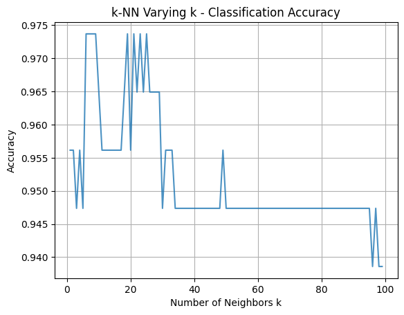

```python
# KNN model

k_values = range(1, 100)
knn_accuracies = []

for k in k_values:
    knn = KNeighborsClassifier(n_neighbors=k)
    knn.fit(X_train, y_train)
    y_pred = knn.predict(X_test)
    knn_accuracies.append(accuracy_score(y_test, y_pred))

plt.plot(k_values, knn_accuracies, linestyle='-', alpha=0.8)
plt.title('k-NN Varying k - Classification Accuracy')
plt.xlabel('Number of Neighbors k')
plt.ylabel('Accuracy')
plt.grid(True)
plt.show()
```

## **Question 3 (5 points):**

## Next, familiarize yourself with the sklearn documentation for each model and their parameters. Pick 2 parameters that you want to adjust from their default values in each of the models.

- https://scikit-learn.org/stable/modules/generated/sklearn.linear_model
- https://scikit-learn.org/stable/modules/generated/sklearn.neighbors.KNeighborsClassifier.html

## Instantiate and fit a logistic regression classifier and a K-Nearest Neighbor model with these **updated** parameters on your clean datasets and target.

```python
# logistic regression classifier

log_reg_updated = LogisticRegression(C=0.5, solver='liblinear')
log_reg_updated.fit(X_train, y_train)

y_pred_log_updated = log_reg_updated.predict(X_test)
acc_log_updated = accuracy_score(y_test, y_pred_log)
print(f"Logistic Regression Accuracy: {acc_log:.2f}")
```

```
Logistic Regression Accuracy: 0.94
```

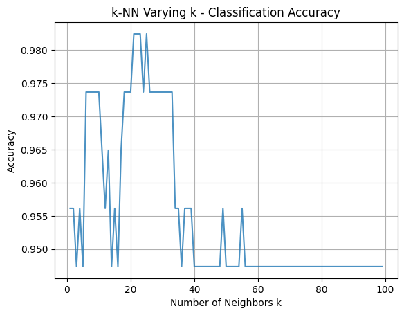

```python
# KNN model

k_values = range(1, 100)
accuracies_updated = []

for k in k_values:
    knn_updated = KNeighborsClassifier(n_neighbors=k, weights='distance', algorithm='ball_tree')
    knn_updated.fit(X_train, y_train)
    y_pred_knn_updated = knn_updated.predict(X_test)
    accuracies_updated.append(accuracy_score(y_test, y_pred_knn_updated))

plt.plot(k_values, accuracies_updated, linestyle = '-', alpha = 0.8)
plt.title('k-NN Varying k - Classification Accuracy')
plt.xlabel('Number of Neighbors k')
plt.ylabel('Accuracy')
plt.grid(True)
plt.show()
```

## **Question 4 (5 points):**

## Compile the following metrics for all 4 of your models into one DataFrame called metrics_df. Each model should have each metric reported.

1. Accuracy Score
2. Precision
3. Recall
4. Sensitivity
5. F1 Score

## The first column of metrics_df has been created for you.

```python
model_strings = ["Default Logistic Regression", "Default KNN", "Updated Logistic Regression", "Updated KNN"]
metrics_df = pd.DataFrame(index = model_strings)
metrics_df["Accuracy Score"] = [0, 0, 0, 0]
metrics_df
```

|  | Accuracy Score |
| --- | --- |
| Default Logistic Regression | 0 |
| Default KNN | 0 |
| Updated Logistic Regression | 0 |
| Updated KNN | 0 |

```python
# gather one accuracy score for the KNN models.
knn = KNeighborsClassifier(n_neighbors = 5)
knn.fit(X_train, y_train)
y_pred_knn = knn.predict(X_test)
acc_knn = accuracy_score(y_test, y_pred_knn)

knn_updated = KNeighborsClassifier(n_neighbors = 5, weights = 'distance', algorithm = 'ball_tree')
knn_updated.fit(X_train, y_train)
y_pred_knn_updated = knn_updated.predict(X_test)
acc_knn_updated = accuracy_score(y_test, y_pred_knn_updated)

# append them to provided dataframe

metrics_df["Accuracy Score"] = [acc_log, acc_knn, acc_log_updated, acc_knn_updated]
metrics_df
```

|  | Accuracy Score |
| --- | --- |
| Default Logistic Regression | 0.938596 |
| Default KNN | 0.947368 |
| Updated Logistic Regression | 0.938596 |
| Updated KNN | 0.947368 |

```python
# calculates  precision, sensitivity, specificity, and F1 scores
def metrics_finder(y_true, y_pred):
    precision = precision_score(y_true, y_pred)
    sensitivity = recall_score(y_true, y_pred)
    specificity = recall_score(np.logical_not(y_true), np.logical_not(y_pred))
    f1 = f1_score(y_true, y_pred)
    return precision, sensitivity, specificity, f1

# add to table

metrics_log = metrics_finder(y_test, y_pred_log)
metrics_knn = metrics_finder(y_test, y_pred_knn)
metrics_log_updated = metrics_finder(y_test, y_pred_log_updated)
metrics_knn_updated = metrics_finder(y_test, y_pred_knn_updated)

metrics_df["Precision"] = [metrics_log[0], metrics_knn[0], metrics_log_updated[0], metrics_knn_updated[0]]
metrics_df["Sensitivity"] = [metrics_log[1], metrics_knn[1], metrics_log_updated[1], metrics_knn_updated[1]]
metrics_df["Specificity"] = [metrics_log[2], metrics_knn[2], metrics_log_updated[2], metrics_knn_updated[2]]
metrics_df["F1 Score"] = [metrics_log[3], metrics_knn[3], metrics_log_updated[3], metrics_knn_updated[3]]

metrics_df
```

|  | Accuracy Score | Precision | Sensitivity | Specificity | F1 Score |
| --- | --- | --- | --- | --- | --- |
| Default Logistic Regression | 0.938596 | 0.928571 | 0.906977 | 0.957746 | 0.917647 |
| Default KNN | 0.947368 | 0.930233 | 0.930233 | 0.957746 | 0.930233 |
| Updated Logistic Regression | 0.938596 | 0.928571 | 0.906977 | 0.957746 | 0.917647 |
| Updated KNN | 0.947368 | 0.930233 | 0.930233 | 0.957746 | 0.930233 |

## Part 2: KNN and Regression Model Evaluation (30 Points)

Let's do some very basic computer vision. We're going to import the MNIST handwritten digits data and NN to predict values (i.e. "see/read").

Run the following cells to download the images and encode them.

```python
from keras.datasets import mnist

train, test = mnist.load_data('minst.db')
X_train, y_train = train
X_test, y_test = test
```

```
7

[[  0   0   0   0   0   0   0   0   0   0   0   0   0   0   0   0   0   0
    0   0   0   0   0   0   0   0   0   0]
 [  0   0   0   0   0   0   0   0   0   0   0   0   0   0   0   0   0   0
    0   0   0   0   0   0   0   0   0   0]
 [  0   0   0   0   0   0   0   0   0   0   0   0   0   0   0   0   0   0
    0   0   0   0   0   0   0   0   0   0]
 [  0   0   0   0   0   0   0   0   0   0   0   0   0   0   0   0   0   0
    0   0   0   0   0   0   0   0   0   0]
 [  0   0   0   0   0   0   0   0   0   0   0   0   0   0   0   0   0   0
    0   0   0   0   0   0   0   0   0   0]
 [  0   0   0   0   0   0   0   0   0   0   0   0   0   0   0   0   0   0
    0   0   0   0   0   0   0   0   0   0]
 [  0   0   0   0   0   0   0   0   0   0   0   0   0   0   0   0   0   0
    0   0   0   0   0   0   0   0   0   0]
 [  0   0   0   0   0   0  84 185 159 151  60  36   0   0   0   0   0   0
    0   0   0   0   0   0   0   0   0   0]
 [  0   0   0   0   0   0 222 254 254 254 254 241 198 198 198 198 198 198
  198 198 170  52   0   0   0   0   0   0]
 [  0   0   0   0   0   0  67 114  72 114 163 227 254 225 254 254 254 250
  229 254 254 140   0   0   0   0   0   0]
 [  0   0   0   0   0   0   0   0   0   0   0  17  66  14  67  67  67  59
   21 236 254 106   0   0   0   0   0   0]
 [  0   0   0   0   0   0   0   0   0   0   0   0   0   0   0   0   0   0
   83 253 209  18   0   0   0   0   0   0]
 [  0   0   0   0   0   0   0   0   0   0   0   0   0   0   0   0   0  22
  233 255  83   0   0   0   0   0   0   0]
 [  0   0   0   0   0   0   0   0   0   0   0   0   0   0   0   0   0 129
  254 238  44   0   0   0   0   0   0   0]
 [  0   0   0   0   0   0   0   0   0   0   0   0   0   0   0   0  59 249
  254  62   0   0   0   0   0   0   0   0]
 [  0   0   0   0   0   0   0   0   0   0   0   0   0   0   0   0 133 254
  187   5   0   0   0   0   0   0   0   0]
 [  0   0   0   0   0   0   0   0   0   0   0   0   0   0   0   9 205 248
   58   0   0   0   0   0   0   0   0   0]
 [  0   0   0   0   0   0   0   0   0   0   0   0   0   0   0 126 254 182
    0   0   0   0   0   0   0   0   0   0]
 [  0   0   0   0   0   0   0   0   0   0   0   0   0   0  75 251 240  57
    0   0   0   0   0   0   0   0   0   0]
 [  0   0   0   0   0   0   0   0   0   0   0   0   0  19 221 254 166   0
    0   0   0   0   0   0   0   0   0   0]
 [  0   0   0   0   0   0   0   0   0   0   0   0   3 203 254 219  35   0
    0   0   0   0   0   0   0   0   0   0]
 [  0   0   0   0   0   0   0   0   0   0   0   0  38 254 254  77   0   0
    0   0   0   0   0   0   0   0   0   0]
 [  0   0   0   0   0   0   0   0   0   0   0  31 224 254 115   1   0   0
    0   0   0   0   0   0   0   0   0   0]
 [  0   0   0   0   0   0   0   0   0   0   0 133 254 254  52   0   0   0
    0   0   0   0   0   0   0   0   0   0]
 [  0   0   0   0   0   0   0   0   0   0  61 242 254 254  52   0   0   0
    0   0   0   0   0   0   0   0   0   0]
 [  0   0   0   0   0   0   0   0   0   0 121 254 254 219  40   0   0   0
    0   0   0   0   0   0   0   0   0   0]
 [  0   0   0   0   0   0   0   0   0   0 121 254 207  18   0   0   0   0
    0   0   0   0   0   0   0   0   0   0]
 [  0   0   0   0   0   0   0   0   0   0   0   0   0   0   0   0   0   0
    0   0   0   0   0   0   0   0   0   0]]
```

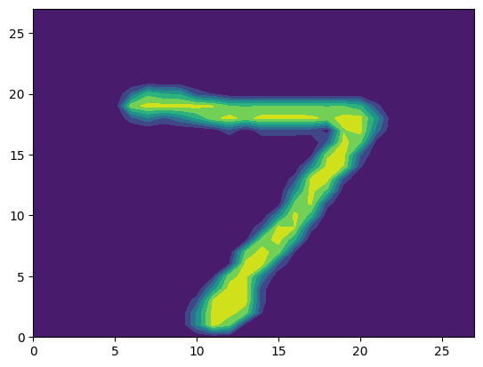

```python
item_index = 0
print(y_test[item_index],'\n') # Print the label
print(X_test[item_index],'\n') # Print the matrix of values
plt.contourf(np.rot90(X_test[item_index].transpose())) # Make a contour plot of the matrix values
plt.show()
```

```
1

[[  0   0   0   0   0   0   0   0   0   0   0   0   0   0   0   0   0   0
    0   0   0   0   0   0   0   0   0   0]
 [  0   0   0   0   0   0   0   0   0   0   0   0   0   0   0   0   0   0
    0   0   0   0   0   0   0   0   0   0]
 [  0   0   0   0   0   0   0   0   0   0   0   0   0   0   0   0   0   0
    0   0   0   0   0   0   0   0   0   0]
 [  0   0   0   0   0   0   0   0   0   0   0   0   0   0   0   0   0   0
    0   0   0   0   0   0   0   0   0   0]
 [  0   0   0   0   0   0   0   0   0   0   0   0   0   0   0   0   0   0
    0   0   0   0   0   0   0   0   0   0]
 [  0   0   0   0   0   0   0   0   0   0   0   0   0   0   0   0  77 254
  107   3   0   0   0   0   0   0   0   0]
 [  0   0   0   0   0   0   0   0   0   0   0   0   0   0   0  19 227 254
  254   9   0   0   0   0   0   0   0   0]
 [  0   0   0   0   0   0   0   0   0   0   0   0   0   0   0  81 254 254
  165   1   0   0   0   0   0   0   0   0]
 [  0   0   0   0   0   0   0   0   0   0   0   0   0   0   7 203 254 254
   73   0   0   0   0   0   0   0   0   0]
 [  0   0   0   0   0   0   0   0   0   0   0   0   0   0  53 254 254 250
    0   0   0   0   0   0   0   0   0   0]
 [  0   0   0   0   0   0   0   0   0   0   0   0   0   0 134 254 254 180
    0   0   0   0   0   0   0   0   0   0]
 [  0   0   0   0   0   0   0   0   0   0   0   0   0   0 196 254 248  48
    0   0   0   0   0   0   0   0   0   0]
 [  0   0   0   0   0   0   0   0   0   0   0   0   0  58 254 254 237   0
    0   0   0   0   0   0   0   0   0   0]
 [  0   0   0   0   0   0   0   0   0   0   0   0   0 111 254 254 132   0
    0   0   0   0   0   0   0   0   0   0]
 [  0   0   0   0   0   0   0   0   0   0   0   0   0 163 254 238  28   0
    0   0   0   0   0   0   0   0   0   0]
 [  0   0   0   0   0   0   0   0   0   0   0   0  60 252 254 223   0   0
    0   0   0   0   0   0   0   0   0   0]
 [  0   0   0   0   0   0   0   0   0   0   0   0  79 254 254 154   0   0
    0   0   0   0   0   0   0   0   0   0]
 [  0   0   0   0   0   0   0   0   0   0   0   0 163 254 238  53   0   0
    0   0   0   0   0   0   0   0   0   0]
 [  0   0   0   0   0   0   0   0   0   0   0  28 252 254 210   0   0   0
    0   0   0   0   0   0   0   0   0   0]
 [  0   0   0   0   0   0   0   0   0   0   0  86 254 254 131   0   0   0
    0   0   0   0   0   0   0   0   0   0]
 [  0   0   0   0   0   0   0   0   0   0   0 105 254 234  20   0   0   0
    0   0   0   0   0   0   0   0   0   0]
 [  0   0   0   0   0   0   0   0   0   0   0 175 254 204   5   0   0   0
    0   0   0   0   0   0   0   0   0   0]
 [  0   0   0   0   0   0   0   0   0   0   5 211 254 196   0   0   0   0
    0   0   0   0   0   0   0   0   0   0]
 [  0   0   0   0   0   0   0   0   0   0   3 158 254 160   0   0   0   0
    0   0   0   0   0   0   0   0   0   0]
 [  0   0   0   0   0   0   0   0   0   0   0  26 157 107   0   0   0   0
    0   0   0   0   0   0   0   0   0   0]
 [  0   0   0   0   0   0   0   0   0   0   0   0   0   0   0   0   0   0
    0   0   0   0   0   0   0   0   0   0]
 [  0   0   0   0   0   0   0   0   0   0   0   0   0   0   0   0   0   0
    0   0   0   0   0   0   0   0   0   0]
 [  0   0   0   0   0   0   0   0   0   0   0   0   0   0   0   0   0   0
    0   0   0   0   0   0   0   0   0   0]]
```

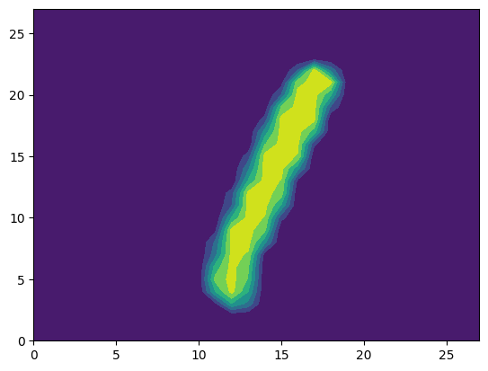

```python
item_index = 5
print(y_test[item_index],'\n') # Print the label
print(X_test[item_index],'\n') # Print the matrix of values
plt.contourf(np.rot90(X_test[item_index].transpose())) # Make a contour plot of the matrix values
plt.show()
```

We will use an already denoised and preprocessed version of the training data.

```python
#! python3 -m pip install pyarrow

Z_train = pd.read_parquet('data/Z_train.parquet', engine='pyarrow')
Z_test = pd.read_parquet('data/Z_test.parquet', engine='pyarrow')
```

## **Question 1 (5 points):**

## What is the shape of X_train and X_test?

## What is the shape of X_train[i] and X_test[i] for each index i?

Hint: All elements of X_train and X_test have the same shape, so you can report the shape of just the first element (i=0)

## What is the shape of Z_train and Z_test?

## What is the shape of y_train and y_test?

## Call the shape function in the code cell below and list your final answers in a text markdown cell.

```python
print("X_train:", X_train.shape)
print("X_test:", X_test.shape)
print("X_train[0]:", X_train[0].shape)
print("X_test[0]:", X_test[0].shape)
print("y_train:", y_train.shape)
print("y_test:", y_test.shape)
print("Z_train:", Z_train.shape)
print("Z_test:", Z_test.shape)
```

```
X_train: (60000, 28, 28)
X_test: (10000, 28, 28)
X_train[0]: (28, 28)
X_test[0]: (28, 28)
y_train: (60000,)
y_test: (10000,)
Z_train: (60000, 784)
Z_test: (10000, 784)
```

X_train and X_test: (60000, 28, 28), (10000, 28, 28)

X_train[i] and X_test[i]: (28, 28), (28, 28)

Z_train and Z_test: (60000, 784), (10000, 784)

y_train and y_test: (60000,), (10000,)

## **Question 2 (5 points):**

## Run the cell below to determine the optimal k number of neighbors from the outputted graph. Report the optimal number and why you believe it is the optimal number in the text markdown cell.

```python
k_bar = 10
k_grid = np.arange(0, k_bar) # The range of k's to consider
accuracy = np.zeros(k_bar) # Empty list of accuracies for each k to update
```

```
Fitting k=0
Fitting k=1
Fitting k=2
Fitting k=3
Fitting k=4
Fitting k=5
Fitting k=6
Fitting k=7
Fitting k=8
Fitting k=9
[2]
```

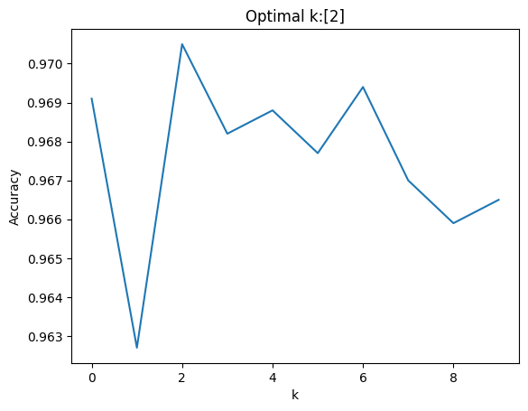

```python
for k in range(k_bar):
    print(f"Fitting k={k}")
    knn = KNeighborsClassifier(n_neighbors=k+1)
    predictor = knn.fit(Z_train.values,y_train)
    accuracy[k] = knn.score(Z_test.values,y_test)

accuracy_max = np.max(accuracy) # Highest recorded accuracy
max_index = np.where(accuracy==accuracy_max)
k_star = k_grid[max_index] # Find the optimal value of k
print(k_star)

plt.plot(np.arange(0,k_bar),accuracy) # Plot accuracy by k
plt.xlabel("k")
plt.title("Optimal k:"+str(k_star))
plt.ylabel('Accuracy')
plt.show()
```

## **Question 3 (10 points):**

## Instantiate and fit a KNN classifier with the optimal number of neighbors from above. Call predict on this KNN model using Z_test. Plot a confusion matrix for the KNN's performance on the test dataset using sklearn's ConfusionMatrixDisplay function.

## In a text markdown cell, explain which mistakes are most likely according to your confusion matrix. Which digits are more likely to be confused for each other? Do you find any interesting patterns?

Write a minimum of 5 sentences.

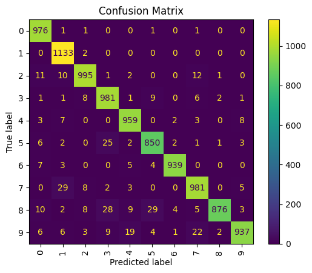

```python
knn_optimal = KNeighborsClassifier(n_neighbors=2)
knn_optimal.fit(Z_train, y_train)

y_pred_knn_optimal = knn_optimal.predict(Z_test)

cm = confusion_matrix(y_test, y_pred_knn_optimal)
disp = ConfusionMatrixDisplay(confusion_matrix=cm)
plt.figure(figsize=(10, 10))
disp.plot(xticks_rotation='vertical')
plt.title('Confusion Matrix')
plt.show()
```

Examining the confusion matrix, we observe that the model generally performs well in classifying most digits accurately. However, certain numbers tend to be misclassified more frequently, particularly 1 and 7, 3 and 8, 3 and 5, 5 and 8, and 7 and 9. These specific digit pairs exhibit a higher rate of misclassification compared to others. While most digits are misclassified only 1 to 15 times, these problematic pairs show misclassification rates exceeding 20 instances. Interestingly, digits such as 0, 1, and 6 appear to have higher classification accuracy, likely due to their more distinct shapes, which result in fewer mix-ups.

## **Question 4 (10 points):**

## ROC curves are typically used to distinguish between two classes by plotting the true positive rate (TPR) against the false positive rate (FPR) at different threshold settings. We will recode the target labels to be only 2 classes: "8" or "not 8"

## Fit a new KNN using binary_y_train and call predict using binary_y_test. Plot the ROC curve and print the AUC score for the new binary data whose code is below.

## Write 2 sentences on how to interpret the resulting ROC curve.

```python
def recode_array(arr, value):
  recoded = np.where(arr == value, 1, 0)
  return recoded
```

```python
binary_y_train = recode_array(y_train, 8)
binary_y_test = recode_array(y_test, 8)
```

```python
# Original target: all digits 0 to 9
y_train
```

```
array([5, 0, 4, ..., 5, 6, 8], dtype=uint8)
```

```python
# New target: all values are 1 (digit 8) or 0 (all other digits)
binary_y_train
```

```
array([0, 0, 0, ..., 0, 0, 1])
```

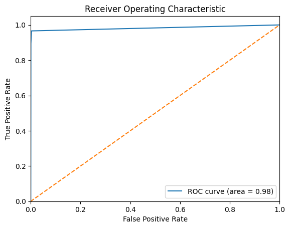

```python
knn_binary = KNeighborsClassifier(n_neighbors=2)
knn_binary.fit(Z_train, binary_y_train)

y_pred_binary = knn_binary.predict_proba(Z_test)[:, 1]

fpr, tpr, _ = roc_curve(binary_y_test, y_pred_binary)
roc_auc = auc(fpr, tpr)

plt.figure()
plt.plot(fpr, tpr, label=f'ROC curve (area = {roc_auc:.2f})')
plt.plot([0, 1], [0, 1], linestyle='--')
plt.xlim([0.0, 1.0])
plt.ylim([0.0, 1.05])
plt.xlabel('False Positive Rate')
plt.ylabel('True Positive Rate')
plt.title('Receiver Operating Characteristic')
plt.legend(loc="lower right")
plt.show()
```

```python
print(f"AUC Score: {roc_auc:.2f}")
```

```
AUC Score: 0.98
```

The ROC curve shows a sharp rise toward the top-left corner almost immediately, which is a strong indicator of the model’s effectiveness. This pattern suggests that the model correctly identifies positive cases at a high rate while minimizing false positives. Additonally, the AUC score is very high, making it clear that the model is making accurate distinctions between classes. A curve like this generally reflects strong overall performance, with the classifier achieving a favorable balance between sensitivity and specificity.

## Part 3: Sampling and Cross Validation (40 points)

We will use the following synthetic dataset to explore cross validation on.

```python
from sklearn.datasets import make_classification

X, y = make_classification(n_samples=1000, n_features=20, n_informative=15, n_redundant=5, random_state=42)
X_train, X_test, y_train, y_test = train_test_split(X, y, test_size=0.3, random_state=42)
```

## **Question 1 (5 points):** Fit a vanilla KNN classifier on the training set and evaluate (predict) on the test set. Store the accuracy of this model in a variable called test_score.

```python
knn_new = KNeighborsClassifier()
knn_new.fit(X_train, y_train)

y_pred_knn_new = knn_new.predict(X_test)

test_score = accuracy_score(y_test, y_pred_knn_new)

print(f"Accuracy Score: {test_score}")
```

```
Accuracy Score: 0.9033333333333333
```

## **Question 2 (10 points):**

## Perform 10-fold cross-validation and compare the results of single split vs. 10-fold cross-validation by plotting accuracy (y-axis) against fold number (x-axis).

## Describe the effect of different fold numbers on the results of cross validation in a text markdown cell and if the results are expected. Give the average accuracy of CV scores across all folds.

Write a minimum of 2 sentences.

```python
from sklearn.model_selection import train_test_split, StratifiedKFold, cross_val_score
```

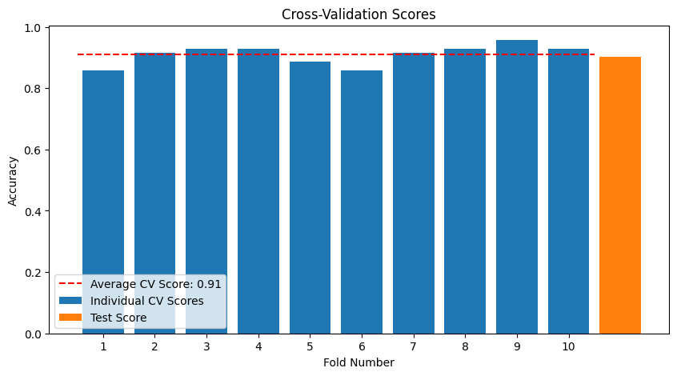

```python
cv = StratifiedKFold(n_splits=10, shuffle=True, random_state=42)

cv_scores = cross_val_score(knn_new, X_train, y_train, cv=cv, scoring='accuracy')

avg_cv_score = np.mean(cv_scores)

plt.figure(figsize=(10, 5))
x_range = np.arange(1, len(cv_scores) + 1)
plt.bar(x_range, cv_scores, label='Individual CV Scores')
plt.bar(len(cv_scores) + 1, test_score, label='Test Score')
plt.plot([0.5, len(cv_scores) + 0.5], [np.mean(cv_scores)]*2, 'r--', label= f'Average CV Score: {avg_cv_score:.2f}')
plt.xlabel('Fold Number')
plt.ylabel('Accuracy')
plt.title('Cross-Validation Scores')
plt.xticks(x_range)
plt.legend()
plt.show()
```

Cross-validation offers a more dependable assessment of the model's performance by averaging results across multiple folds, providing a clearer picture of how the model performs when the data is shuffled. This approach led to a higher average score compared to a single test score, which is expected since it captures more variability in the data, leading to a more precise evaluation. With cross-validation, the model achieved an average accuracy of 0.91.

## **Question 3 (5 points):**

## Modify the plot above and add:

1. A horizontal static red line corresponding to the single split model accuracy
2. A horizontal green line corresponding to the average CV fold accuracy

## You may use the following code to achieve these:

> plt.axhline(y=test_score, color='r', linestyle='--', label='Single Test Score')

> plt.axhline(y=np.mean(cv_scores), color='g', linestyle='-', label='Average CV Score')

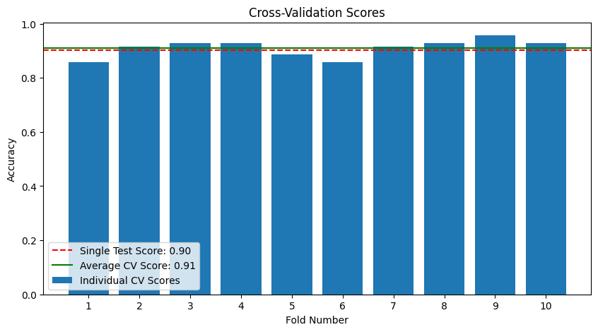

```python
plt.figure(figsize=(10, 5))
x_range = np.arange(1, len(cv_scores) + 1)
plt.bar(x_range, cv_scores, label='Individual CV Scores')
plt.axhline(y=test_score, color='r', linestyle='--', label=f'Single Test Score: {test_score:.2f}')
plt.axhline(y=np.mean(cv_scores), color='g', linestyle='-', label= f'Average CV Score: {avg_cv_score:.2f}')
plt.xlabel('Fold Number')
plt.ylabel('Accuracy')
plt.title('Cross-Validation Scores')
plt.xticks(x_range)
plt.legend()
plt.show()
```

## **Question 4 (10 points):**

## Implement 5-fold cross-validation on a dataset of your choice. Complete any necessary preprocessing (you may reuse the dataset from Part 1).

## Implement a train-test split and instantiate a classification model of your choice. Call predict on (evaluate) both a single-split and 5-fold CV model.

```python
x = df.iloc[:, 1:11]
y = df['diagnosis_encoded']

X_train, X_test, y_train, y_test = train_test_split(x, y, test_size=0.2, random_state=42)

knn_bc = KNeighborsClassifier(n_neighbors=20)
knn_bc.fit(X_train, y_train)

y_pred_bc = knn_bc.predict(X_test)

test_score_bc = accuracy_score(y_test, y_pred_bc)

print(f"Accuracy Score: {test_score}")
```

```
Accuracy Score: 0.9033333333333333
```

```python
cv = StratifiedKFold(n_splits=5, shuffle=True, random_state=42)
scores = cross_val_score(knn_bc, x, y, cv=cv, scoring='accuracy')
```

```python
average_score = np.mean(scores)
print(f"Average Accuracy of Cross-Validation Scores: {average_score:.2f}")
print(f"Single Split Accuracy: {test_score_bc:.2f}")
```

```
Average Accuracy of Cross-Validation Scores: 0.94
Single Split Accuracy: 0.96
```

## **Question 5 (10 points):**

## Finally, create the same plot as in Question 3 to compare single-split with CV performance on your chosen dataset.

## The plot should have Fold Number on the x-axis and Accuracy on the y-axis. Include a horizontal red line for the single-split accuracy and a horizontal green line for the average CV fold score.

[figure not shown]

```python
plt.figure(figsize=(10, 5))
x_range = np.arange(1, len(scores) + 1)
plt.bar(x_range, scores, label='Individual CV Scores')
plt.axhline(y=test_score_bc, color='r', linestyle='--', label=f'Single Test Score: {test_score_bc:.2f}')
plt.axhline(y=np.mean(scores), color='g', linestyle='-', label= f'Average CV Score: {avg_cv_score:.2f}')
plt.xlabel('Fold Number')
plt.ylabel('Accuracy')
plt.title('Cross-Validation Scores')
plt.xticks(x_range)
plt.legend()
plt.show()
```

### Honor Pledge

On my honor as a student, I have neither given nor received unauthorized aid on this assignment.